# Examples

This page provides runnable examples for every surrogate type in GeoSurrogates.jl.

## Setup

First, let’s load the packages and create some sample data to work with.

```julia
using GeoSurrogates
using Rasters
using DimensionalData
using Statistics
using Zygote  # Required for neural network training
using CairoMakie  # For plotting

# Create sample elevation data (a simple hill)
# Using 51 points so that 0.0 is exactly on the grid
xs = range(-1, 1, length=51)
ys = range(-1, 1, length=51)
elevation_data = [exp(-(x^2 + y^2)) for x in xs, y in ys]
elev = Raster(elevation_data, (X(xs), Y(ys)))

# Create sample categorical data (3 classes based on elevation)
cat_data = map(elevation_data) do v
    v < 0.3 ? 1 : v < 0.7 ? 2 : 3
end
veg = Raster(cat_data, (X(xs), Y(ys)))

# Create sample wind data (circular flow)
u_data = [-y for x in xs, y in ys]
v_data = [x for x in xs, y in ys]
u_wind = Raster(u_data, (X(xs), Y(ys)))
v_wind = Raster(v_data, (X(xs), Y(ys)))

println("Sample data created (51x51 grids with 0.0 on grid):")
println("  elev: $(size(elev)) elevation raster")
println("  veg:  $(size(veg)) categorical raster (classes: $(sort(unique(veg))))")
println("  u_wind, v_wind: $(size(u_wind)) wind component rasters")
```

```
Sample data created (51x51 grids with 0.0 on grid):
  elev: (51, 51) elevation raster
  veg:  (51, 51) categorical raster (classes: [1, 2, 3])
  u_wind, v_wind: (51, 51) wind component rasters
```

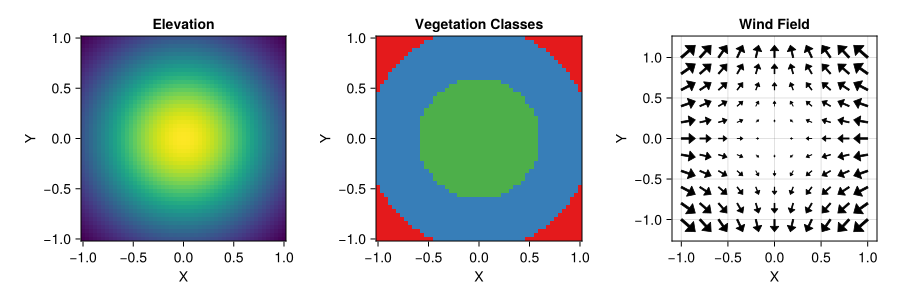

Figure 3.1: Sample data: elevation (left), vegetation classes (center), wind field (right)

```julia
fig = Figure(size=(900, 300))
ax1 = Axis(fig[1, 1], title="Elevation", xlabel="X", ylabel="Y", aspect=1)
heatmap!(ax1, collect(xs), collect(ys), elevation_data, colormap=:viridis)

ax2 = Axis(fig[1, 2], title="Vegetation Classes", xlabel="X", ylabel="Y", aspect=1)
heatmap!(ax2, collect(xs), collect(ys), cat_data, colormap=:Set1_3)

ax3 = Axis(fig[1, 3], title="Wind Field", xlabel="X", ylabel="Y", aspect=1)
# Subsample for arrow visibility
step = 5
arrow_xs = xs[1:step:end]
arrow_ys = ys[1:step:end]
u_sub = u_data[1:step:end, 1:step:end]
v_sub = v_data[1:step:end, 1:step:end]
arrows2d!(ax3, [x for x in arrow_xs for _ in arrow_ys], [y for _ in arrow_xs for y in arrow_ys],
        vec(u_sub), vec(v_sub), lengthscale=0.15, color=:black)
fig
```

## Classical Surrogates

### LinReg

Linear regression surrogate for simple trend modeling.

```julia
using StatsModels

# Fit a quadratic model
linreg_model = LinReg(elev, @formula(layer1 ~ 1 + X + Y + X^2 + Y^2))

# Predict at a single point
val = predict(linreg_model, (0.0, 0.0))
println("Prediction at (0, 0): $val")

# Predict on the full raster
linreg_predicted = predict(linreg_model, elev)
error = mean(abs.(elev .- linreg_predicted))
println("Mean absolute error: $(round(error, digits=4))")
```

```
Prediction at (0, 0): 0.884536374002216
Mean absolute error: 0.0407
```

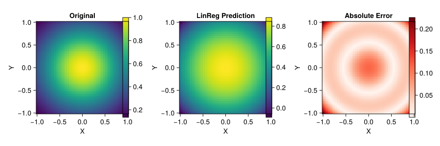

Figure 3.2: LinReg: Original elevation (left) vs quadratic fit (center) and error (right)

```julia
fig = Figure(size=(900, 300))
ax1 = Axis(fig[1, 1], title="Original", xlabel="X", ylabel="Y", aspect=1)
hm1 = heatmap!(ax1, collect(xs), collect(ys), elevation_data, colormap=:viridis)
Colorbar(fig[1, 1][1, 2], hm1)

ax2 = Axis(fig[1, 2], title="LinReg Prediction", xlabel="X", ylabel="Y", aspect=1)
hm2 = heatmap!(ax2, collect(xs), collect(ys), Matrix(linreg_predicted), colormap=:viridis)
Colorbar(fig[1, 2][1, 2], hm2)

ax3 = Axis(fig[1, 3], title="Absolute Error", xlabel="X", ylabel="Y", aspect=1)
hm3 = heatmap!(ax3, collect(xs), collect(ys), abs.(elevation_data .- Matrix(linreg_predicted)), colormap=:Reds)
Colorbar(fig[1, 3][1, 2], hm3)
fig
```

### IDW (Inverse Distance Weighting)

Simple scattered-data interpolation that weights nearby points more heavily.

```julia
# Fit IDW with default power=2
idw_model = IDW(elev)

# Predict at a single point
val = predict(idw_model, (0.0, 0.0))
println("IDW prediction at (0, 0): $(round(val, digits=4))")

# Predict on the full raster
idw_predicted = predict(idw_model, elev)
error = mean(abs.(elev .- idw_predicted))
println("Mean absolute error: $(round(error, digits=6))")
```

```
IDW prediction at (0, 0): 1.0
Mean absolute error: 0.0
```

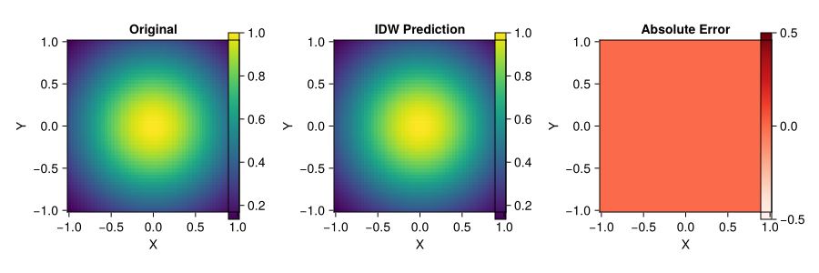

Figure 3.3: IDW: Original elevation (left) vs IDW interpolation (center) and error (right)

```julia
fig = Figure(size=(900, 300))
ax1 = Axis(fig[1, 1], title="Original", xlabel="X", ylabel="Y", aspect=1)
hm1 = heatmap!(ax1, collect(xs), collect(ys), elevation_data, colormap=:viridis)
Colorbar(fig[1, 1][1, 2], hm1)

ax2 = Axis(fig[1, 2], title="IDW Prediction", xlabel="X", ylabel="Y", aspect=1)
hm2 = heatmap!(ax2, collect(xs), collect(ys), Matrix(idw_predicted), colormap=:viridis)
Colorbar(fig[1, 2][1, 2], hm2)

ax3 = Axis(fig[1, 3], title="Absolute Error", xlabel="X", ylabel="Y", aspect=1)
hm3 = heatmap!(ax3, collect(xs), collect(ys), abs.(elevation_data .- Matrix(idw_predicted)), colormap=:Reds)
Colorbar(fig[1, 3][1, 2], hm3)
fig
```

### RBF (Radial Basis Function)

Kernel-based interpolation with several built-in kernels. Supports optional polynomial augmentation.

```julia
# Fit RBF with Gaussian kernel
rbf_model = RBF(elev; kernel=:gaussian, epsilon=1.0)

# Predict at a single point
val = predict(rbf_model, (0.0, 0.0))
println("RBF prediction at (0, 0): $(round(val, digits=4))")

# Predict on the full raster
rbf_predicted = predict(rbf_model, elev)
error = mean(abs.(elev .- rbf_predicted))
println("Mean absolute error: $(round(error, digits=6))")
```

```
RBF prediction at (0, 0): 1.0
Mean absolute error: 0.0
```

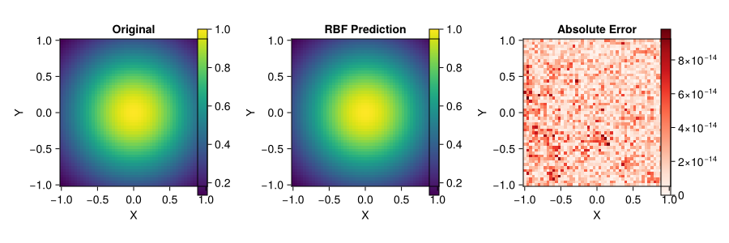

Figure 3.4: RBF: Original elevation (left) vs RBF interpolation (center) and error (right)

```julia
fig = Figure(size=(900, 300))
ax1 = Axis(fig[1, 1], title="Original", xlabel="X", ylabel="Y", aspect=1)
hm1 = heatmap!(ax1, collect(xs), collect(ys), elevation_data, colormap=:viridis)
Colorbar(fig[1, 1][1, 2], hm1)

ax2 = Axis(fig[1, 2], title="RBF Prediction", xlabel="X", ylabel="Y", aspect=1)
hm2 = heatmap!(ax2, collect(xs), collect(ys), Matrix(rbf_predicted), colormap=:viridis)
Colorbar(fig[1, 2][1, 2], hm2)

ax3 = Axis(fig[1, 3], title="Absolute Error", xlabel="X", ylabel="Y", aspect=1)
hm3 = heatmap!(ax3, collect(xs), collect(ys), abs.(elevation_data .- Matrix(rbf_predicted)), colormap=:Reds)
Colorbar(fig[1, 3][1, 2], hm3)
fig
```

### TPS (Thin Plate Spline)

Thin plate spline interpolation with optional regularization for smoothing.

```julia
# Fit TPS (exact interpolation by default)
tps_model = TPS(elev)

# Predict at a single point
val = predict(tps_model, (0.0, 0.0))
println("TPS prediction at (0, 0): $(round(val, digits=4))")

# Predict on the full raster
tps_predicted = predict(tps_model, elev)
error = mean(abs.(elev .- tps_predicted))
println("Mean absolute error: $(round(error, digits=6))")

# With smoothing
tps_smooth = TPS(elev; regularization=0.01)
tps_smooth_predicted = predict(tps_smooth, elev)
smooth_error = mean(abs.(elev .- tps_smooth_predicted))
println("Smoothed TPS MAE: $(round(smooth_error, digits=4))")
```

[output not shown]

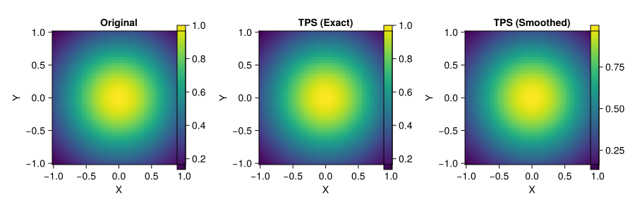

Figure 3.5: TPS: Original elevation (left) vs exact TPS (center) and smoothed TPS (right)

```julia
fig = Figure(size=(900, 300))
ax1 = Axis(fig[1, 1], title="Original", xlabel="X", ylabel="Y", aspect=1)
hm1 = heatmap!(ax1, collect(xs), collect(ys), elevation_data, colormap=:viridis)
Colorbar(fig[1, 1][1, 2], hm1)

ax2 = Axis(fig[1, 2], title="TPS (Exact)", xlabel="X", ylabel="Y", aspect=1)
hm2 = heatmap!(ax2, collect(xs), collect(ys), Matrix(tps_predicted), colormap=:viridis)
Colorbar(fig[1, 2][1, 2], hm2)

ax3 = Axis(fig[1, 3], title="TPS (Smoothed)", xlabel="X", ylabel="Y", aspect=1)
hm3 = heatmap!(ax3, collect(xs), collect(ys), Matrix(tps_smooth_predicted), colormap=:viridis)
Colorbar(fig[1, 3][1, 2], hm3)
fig
```

### RasterWrap

Interpolation-based surrogate using B-splines. Provides exact interpolation at grid points.

```julia
using Interpolations

# Create interpolation wrapper (default: linear B-spline)
rw = RasterWrap(elev)

# Predict at grid points (exact)
original_val = elev[X=At(0.0), Y=At(0.0)]
predicted_val = predict(rw, (0.0, 0.0))
println("Original value at (0,0): $original_val")
println("Predicted value at (0,0): $predicted_val")

# Predict at off-grid point (interpolated)
offgrid_val = predict(rw, (0.01, 0.01))
println("Interpolated value at (0.01, 0.01): $(round(offgrid_val, digits=4))")

# Predict on a finer grid
fine_xs = range(-1, 1, length=100)
fine_ys = range(-1, 1, length=100)
fine_raster = Raster(zeros(100, 100), (X(fine_xs), Y(fine_ys)))
upsampled = predict(rw, fine_raster)
println("Upsampled from $(size(elev)) to $(size(upsampled))")
```

```
Original value at (0,0): 1.0
Predicted value at (0,0): 1.0
Interpolated value at (0.01, 0.01): 0.9992
Upsampled from (51, 51) to (100, 100)
```

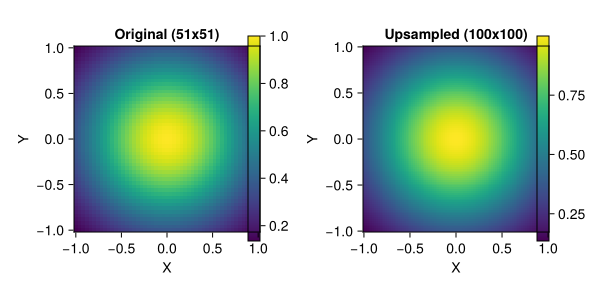

Figure 3.6: RasterWrap: Original 51x51 grid (left) upsampled to 100x100 (right)

```julia
fig = Figure(size=(600, 300))
ax1 = Axis(fig[1, 1], title="Original (51x51)", xlabel="X", ylabel="Y", aspect=1)
hm1 = heatmap!(ax1, collect(xs), collect(ys), elevation_data, colormap=:viridis)
Colorbar(fig[1, 1][1, 2], hm1)

ax2 = Axis(fig[1, 2], title="Upsampled (100x100)", xlabel="X", ylabel="Y", aspect=1)
hm2 = heatmap!(ax2, collect(fine_xs), collect(fine_ys), Matrix(upsampled), colormap=:viridis)
Colorbar(fig[1, 2][1, 2], hm2)
fig
```

### CategoricalRasterWrap

Kernel smoothing surrogate for categorical data. Returns probability distributions over classes.

```julia
# Create categorical wrapper
crw = CategoricalRasterWrap(veg)

# Predict probabilities at center (should favor class 3 - highest elevation)
probs = predict(crw, (0.0, 0.0))
println("Class probabilities at (0, 0):")
for (k, v) in sort(collect(probs), by=first)
    println("  Class $k: $(round(v, digits=3))")
end

# Predict at edge (should favor class 1 - lowest elevation)
probs_edge = predict(crw, (0.9, 0.9))
println("\nClass probabilities at (0.9, 0.9):")
for (k, v) in sort(collect(probs_edge), by=first)
    println("  Class $k: $(round(v, digits=3))")
end
```

```
Class probabilities at (0, 0):
  Class 1: 0.0
  Class 2: 0.053
  Class 3: 0.947

Class probabilities at (0.9, 0.9):
  Class 1: 0.568
  Class 2: 0.418
  Class 3: 0.014
```

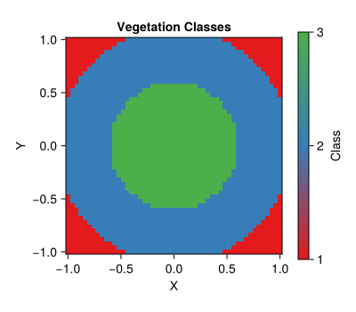

Figure 3.7: CategoricalRasterWrap: Categorical vegetation classes

```julia
fig = Figure(size=(400, 350))
ax = Axis(fig[1, 1], title="Vegetation Classes", xlabel="X", ylabel="Y", aspect=1)
hm = heatmap!(ax, collect(xs), collect(ys), cat_data, colormap=:Set1_3)
Colorbar(fig[1, 2], hm, label="Class", ticks=1:3)
fig
```

### GeomWrap

Geometry-based surrogate using distance kernels. Points near the geometry have values close to 1.

```julia
import GeoInterface as GI

# Create a point geometry at the origin
pt = GI.Point(0.0, 0.0)
gw = GeomWrap(pt)

# Predict at the point itself
val_at_point = predict(gw, (0.0, 0.0))
println("Value at geometry: $val_at_point")

# Predict at increasing distances
for dist in [0.1, 0.25, 0.5, 1.0]
    val = predict(gw, (dist, 0.0))
    println("Value at distance $dist: $(round(val, digits=4))")
end

# Create influence raster
influence = predict(gw, elev)
println("\nInfluence raster range: $(round(minimum(influence), digits=4)) to $(round(maximum(influence), digits=4))")
```

```
Value at geometry: 1.0
Value at distance 0.1: 0.9231
Value at distance 0.25: 0.6065
Value at distance 0.5: 0.1353
Value at distance 1.0: 0.0003

Influence raster range: 0.0 to 1.0
```

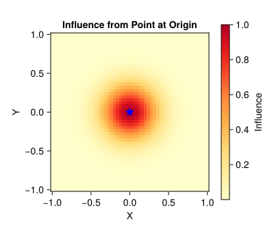

Figure 3.8: GeomWrap: Distance-based influence from a point at the origin

```julia
fig = Figure(size=(400, 350))
ax = Axis(fig[1, 1], title="Influence from Point at Origin", xlabel="X", ylabel="Y", aspect=1)
hm = heatmap!(ax, collect(xs), collect(ys), Matrix(influence), colormap=:YlOrRd)
scatter!(ax, [0.0], [0.0], color=:blue, markersize=15, marker=:star5)
Colorbar(fig[1, 2], hm, label="Influence")
fig
```

## Neural Network Surrogates

Neural network surrogates require normalized data (values in [-1, 1]).

### ImplicitTerrain.MLP

Single SIREN network for scalar field approximation.

```julia
# Normalize the elevation data
elev_norm = normalize(elev)
println("Normalized elevation range: $(extrema(elev_norm))")

# Create and train MLP
mlp = ImplicitTerrain.MLP(hidden=64, n_hidden=2)  # Smaller network for demo
fit!(mlp, elev_norm; steps=2000)

# Predict
mlp_predicted = predict(mlp, elev_norm)
error = mean(abs.(elev_norm .- mlp_predicted))
println("Mean absolute error after 2000 steps: $(round(error, digits=4))")
```

```
Normalized elevation range: (-1.0, 1.0)
Mean absolute error after 2000 steps: 0.0329
```

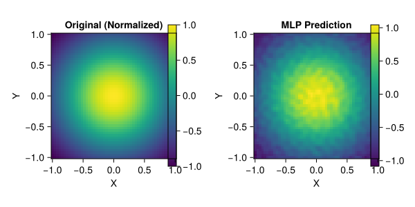

Figure 3.9: ImplicitTerrain.MLP: Original normalized elevation (left) vs neural network prediction (right)

```julia
fig = Figure(size=(600, 300))
ax1 = Axis(fig[1, 1], title="Original (Normalized)", xlabel="X", ylabel="Y", aspect=1)
hm1 = heatmap!(ax1, collect(xs), collect(ys), Matrix(elev_norm), colormap=:viridis)
Colorbar(fig[1, 1][1, 2], hm1)

ax2 = Axis(fig[1, 2], title="MLP Prediction", xlabel="X", ylabel="Y", aspect=1)
hm2 = heatmap!(ax2, collect(xs), collect(ys), Matrix(mlp_predicted), colormap=:viridis)
Colorbar(fig[1, 2][1, 2], hm2)
fig
```

### ImplicitTerrain.Model

Cascaded SIREN with surface and geometry components, trained progressively.

```julia
# Create the cascaded model
terrain_model = ImplicitTerrain.Model()

# Fit with progressive Gaussian pyramid training
fit!(terrain_model, elev_norm; steps=500)

# Predict
terrain_predicted = predict(terrain_model, elev_norm)
error = mean(abs.(elev_norm .- terrain_predicted))
println("Mean absolute error: $(round(error, digits=4))")

# The model combines surface (broad features) + geometry (fine details)
surface_pred = predict(terrain_model.surface, elev_norm)
geometry_pred = predict(terrain_model.geometry, elev_norm)
println("Surface contribution range: $(round.(extrema(surface_pred), digits=3))")
println("Geometry contribution range: $(round.(extrema(geometry_pred), digits=3))")
```

```
[ Info: Fitting surface model on pyramid level 1/3 with size (6, 6)
[ Info: Fitting surface model on pyramid level 2/3 with size (12, 12)
[ Info: Fitting surface model on pyramid level 3/3 with size (25, 25)
┌ Info: Fitting geometry model on residuals with size (51, 51)
└   residual_range = (-0.48283437f0, 0.35338765f0)
Mean absolute error: 0.0333
Surface contribution range: (-1.05f0, 1.064f0)
Geometry contribution range: (-0.445f0, 0.364f0)
```

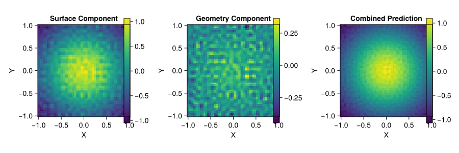

Figure 3.10: ImplicitTerrain.Model: Surface component (left), geometry component (center), combined prediction (right)

```julia
fig = Figure(size=(900, 300))
ax1 = Axis(fig[1, 1], title="Surface Component", xlabel="X", ylabel="Y", aspect=1)
hm1 = heatmap!(ax1, collect(xs), collect(ys), Matrix(surface_pred), colormap=:viridis)
Colorbar(fig[1, 1][1, 2], hm1)

ax2 = Axis(fig[1, 2], title="Geometry Component", xlabel="X", ylabel="Y", aspect=1)
hm2 = heatmap!(ax2, collect(xs), collect(ys), Matrix(geometry_pred), colormap=:viridis)
Colorbar(fig[1, 2][1, 2], hm2)

ax3 = Axis(fig[1, 3], title="Combined Prediction", xlabel="X", ylabel="Y", aspect=1)
hm3 = heatmap!(ax3, collect(xs), collect(ys), Matrix(terrain_predicted), colormap=:viridis)
Colorbar(fig[1, 3][1, 2], hm3)
fig
```

### WindSurrogate.WindSIREN

SIREN network for 2D vector fields (u, v wind components).

```julia
# Normalize wind components
u_norm = normalize(u_wind)
v_norm = normalize(v_wind)

# Create and train WindSIREN
wind_model = WindSurrogate.WindSIREN(hidden=64, n_hidden=2)
fit!(wind_model, u_norm, v_norm; steps=2000)

# Predict returns tuple of (u_raster, v_raster)
u_pred, v_pred = predict(wind_model, u_norm)

u_error = mean(abs.(u_norm .- u_pred))
v_error = mean(abs.(v_norm .- v_pred))
println("U component MAE: $(round(u_error, digits=4))")
println("V component MAE: $(round(v_error, digits=4))")

# Predict at single point
u_val, v_val = predict(wind_model, (0.0, 0.0))
println("\nWind at (0, 0): u=$(round(u_val, digits=3)), v=$(round(v_val, digits=3))")
println("Expected: u≈0, v≈0 (center of circular flow)")
```

```
U component MAE: 0.0504
V component MAE: 0.0486

Wind at (0, 0): u=-0.034, v=0.067
Expected: u≈0, v≈0 (center of circular flow)
```

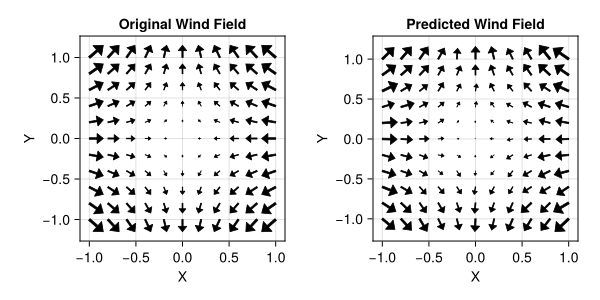

Figure 3.11: WindSIREN: Original wind field (left) vs predicted wind field (right)

```julia
fig = Figure(size=(600, 300))

ax1 = Axis(fig[1, 1], title="Original Wind Field", xlabel="X", ylabel="Y", aspect=1)
arrows2d!(ax1, [x for x in arrow_xs for _ in arrow_ys], [y for _ in arrow_xs for y in arrow_ys],
        vec(u_sub), vec(v_sub), lengthscale=0.15, color=:black)

ax2 = Axis(fig[1, 2], title="Predicted Wind Field", xlabel="X", ylabel="Y", aspect=1)
u_pred_sub = Matrix(u_pred)[1:step:end, 1:step:end]
v_pred_sub = Matrix(v_pred)[1:step:end, 1:step:end]
arrows2d!(ax2, [x for x in arrow_xs for _ in arrow_ys], [y for _ in arrow_xs for y in arrow_ys],
        vec(u_pred_sub), vec(v_pred_sub), lengthscale=0.15, color=:black)
fig
```

### CatSIREN.CatSIREN

SIREN network for categorical/classification tasks with softmax output.

```julia
# Create CatSIREN from raster (auto-detects classes)
cat_model = CatSIREN.CatSIREN(veg; hidden=64, n_hidden=2)
println("Detected classes: $(cat_model.classes)")

# Train
fit!(cat_model, veg; steps=1000)

# Predict probabilities at center
probs = predict(cat_model, (0.0, 0.0))
println("\nPredicted probabilities at (0, 0):")
for (k, v) in sort(collect(probs), by=first)
    println("  Class $k: $(round(v, digits=3))")
end

# Predict most likely class
predicted_class = CatSIREN.predict_class(cat_model, (0.0, 0.0))
actual_class = veg[X=At(0.0), Y=At(0.0)]
println("\nPredicted class at (0,0): $predicted_class")
println("Actual class at (0,0): $actual_class")

# Predict classes for full raster
class_raster = CatSIREN.predict_class(cat_model, veg)
accuracy = mean(class_raster .== veg)
println("Overall accuracy: $(round(accuracy * 100, digits=1))%")
```

```
Detected classes: [1, 2, 3]

Predicted probabilities at (0, 0):
  Class 1: 0.027
  Class 2: 0.063
  Class 3: 0.91

Predicted class at (0,0): 3
Actual class at (0,0): 3
Overall accuracy: 99.6%
```

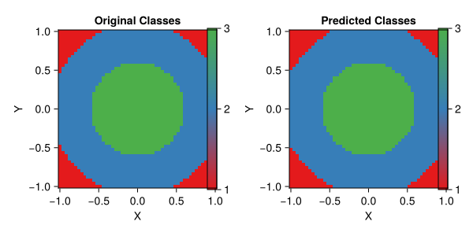

Figure 3.12: CatSIREN: Original classes (left) vs predicted classes (right)

```julia
fig = Figure(size=(600, 300))
ax1 = Axis(fig[1, 1], title="Original Classes", xlabel="X", ylabel="Y", aspect=1)
hm1 = heatmap!(ax1, collect(xs), collect(ys), cat_data, colormap=:Set1_3)
Colorbar(fig[1, 1][1, 2], hm1, ticks=1:3)

ax2 = Axis(fig[1, 2], title="Predicted Classes", xlabel="X", ylabel="Y", aspect=1)
hm2 = heatmap!(ax2, collect(xs), collect(ys), Matrix(class_raster), colormap=:Set1_3)
Colorbar(fig[1, 2][1, 2], hm2, ticks=1:3)
fig
```

## Composite Surrogates

### AdditiveModel

A boosting-style composite that fits each model to the residuals of the previous models. This example combines a `LinReg` (captures the broad trend) with an `ImplicitTerrain.MLP` (captures the fine details the regression misses).

```julia
using StatsModels
using GeoSurrogates.Optimisers: Adam

# Build an AdditiveModel: LinReg first, then MLP on the residual
additive = AdditiveModel([
    LinReg(elev_norm, @formula(layer1 ~ 1 + X + Y + X^2 + Y^2)),
    ImplicitTerrain.MLP(hidden=64, n_hidden=2, alg=Adam(0.001f0))
])

# fit! trains each model sequentially on the residuals
fit!(additive, elev_norm; steps=2000)

# Predict on the full raster
additive_predicted = predict(additive, elev_norm)

# Compare errors
linreg_only = predict(additive.models[1], elev_norm)
linreg_error = mean(abs.(elev_norm .- linreg_only))
additive_error = mean(abs.(elev_norm .- additive_predicted))
println("LinReg-only MAE:     $(round(linreg_error, digits=4))")
println("AdditiveModel MAE:   $(round(additive_error, digits=4))")
```

```
LinReg-only MAE:     0.0942
AdditiveModel MAE:   0.005
```

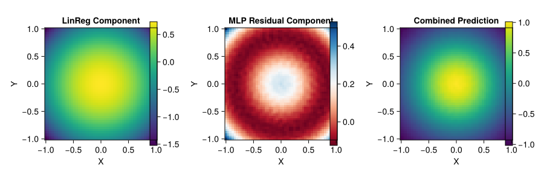

Figure 3.13: AdditiveModel: LinReg captures the trend (left), MLP fits the residual (center), combined prediction (right)

```julia
residual_pred = predict(additive.models[2], elev_norm)

fig = Figure(size=(900, 300))
ax1 = Axis(fig[1, 1], title="LinReg Component", xlabel="X", ylabel="Y", aspect=1)
hm1 = heatmap!(ax1, collect(xs), collect(ys), Matrix(linreg_only), colormap=:viridis)
Colorbar(fig[1, 1][1, 2], hm1)

ax2 = Axis(fig[1, 2], title="MLP Residual Component", xlabel="X", ylabel="Y", aspect=1)
hm2 = heatmap!(ax2, collect(xs), collect(ys), Matrix(residual_pred), colormap=:RdBu)
Colorbar(fig[1, 2][1, 2], hm2)

ax3 = Axis(fig[1, 3], title="Combined Prediction", xlabel="X", ylabel="Y", aspect=1)
hm3 = heatmap!(ax3, collect(xs), collect(ys), Matrix(additive_predicted), colormap=:viridis)
Colorbar(fig[1, 3][1, 2], hm3)
fig
```

## Summary

| Surrogate | Input | Output | Use Case |
| --- | --- | --- | --- |
| `LinReg` | Raster | Scalar | Simple trends |
| `IDW` | Raster | Scalar | Inverse distance weighting |
| `RBF` | Raster | Scalar | Kernel-based interpolation |
| `TPS` | Raster | Scalar | Thin plate spline interpolation |
| `RasterWrap` | Raster | Scalar | Exact interpolation |
| `CategoricalRasterWrap` | Categorical Raster | Probability Dict | Categorical smoothing |
| `GeomWrap` | Geometry | Scalar [0,1] | Distance-based influence |
| `ImplicitTerrain.MLP` | Normalized Raster | Scalar | Neural compression |
| `ImplicitTerrain.Model` | Normalized Raster | Scalar | High-quality terrain |
| `WindSIREN` | Two Normalized Rasters | (Scalar, Scalar) | Vector fields |
| `CatSIREN` | Categorical Raster | Probability Dict | Neural classification |
| `AdditiveModel` | Raster | Scalar | Boosting / residual fitting |